# HW_7

Jillian Sarazen

2/26/2020

## Homework #7: Creating Fake Data Sets To Explore Hypotheses

#### Data in each of your treatment groups follow a normal distribution. Specify the sample sizes, means, and variances for each group that would be reasonable if your hypothesis were true.

```r
# this section of code sets the parameters of the data, SD, mean, sample size
n_group <- 2 # number of treatment groups
n_names <- c("WCB1", "WCB2") # WCB1 = woodchip bioreactor 1 (and 2, there are 2 outflows)
n_size <- c(14,15) # size is number of samples, aka number of storm events
n_mean <- c(23.79,45.39) # means of the two groups
n_sd <- c(13.57,25.24)
t_group <- rep(n_names,n_size) # this makes a t_group that has names of the treatment groups repeated for the whole sample size
t_group
```

```
##  [1] "WCB1" "WCB1" "WCB1" "WCB1" "WCB1" "WCB1" "WCB1" "WCB1" "WCB1" "WCB1"
## [11] "WCB1" "WCB1" "WCB1" "WCB1" "WCB2" "WCB2" "WCB2" "WCB2" "WCB2" "WCB2"
## [21] "WCB2" "WCB2" "WCB2" "WCB2" "WCB2" "WCB2" "WCB2" "WCB2" "WCB2"
```

```r
table(t_group)
```

```
## t_group
## WCB1 WCB2
##   14   15
```

# this chunk of code sets up the data frame, one column is id, then t_group (made above, all the treatments)

```r
id <- 1:(sum(n_size)) # the sum of both samples from both groups
# random normal numbers to make up the value column (in my case TN values)
res_var <- c(rnorm(n=n_size[1],mean=n_mean[1],sd=n_sd[1]),
             rnorm(n=n_size[2],mean=n_mean[2],sd=n_sd[2]))

ano_data <- data.frame(id,t_group,res_var)
str(ano_data)
```

```
## 'data.frame':    29 obs. of  3 variables:
##  $ id     : int  1 2 3 4 5 6 7 8 9 10 ...
##  $ t_group: Factor w/ 2 levels "WCB1","WCB2": 1 1 1 1 1 1 1 1 1 1 ...
##  $ res_var: num  34.6 32.7 20.4 48.2 31.9 ...
```

## Running ANOVA model

```r
# ~ means "as a function of"
ano_model <- aov(res_var~t_group,data=ano_data)
print(ano_model) # to get the model
```

```
## Call:
##    aov(formula = res_var ~ t_group, data = ano_data)
##
## Terms:
##                  t_group Residuals
## Sum of Squares  6000.080  5231.887
## Deg. of Freedom        1        27
##
## Residual standard error: 13.92026
## Estimated effects may be unbalanced
```

```r
print(summary(ano_model)) # gets all elements of the model
```

```
##             Df Sum Sq Mean Sq F value   Pr(>F)
## t_group      1   6000    6000   30.96 6.71e-06 ***
## Residuals   27   5232     194
## ---
## Signif. codes:  0 '***' 0.001 '**' 0.01 '*' 0.05 '.' 0.1 ' ' 1
```

```r
z <- summary(ano_model) # save as a vector
str(z)
```

```
## List of 1
##  $ :Classes 'anova' and 'data.frame':    2 obs. of  5 variables:
##   ..$ Df     : num [1:2] 1 27
##   ..$ Sum Sq : num [1:2] 6000 5232
##   ..$ Mean Sq: num [1:2] 6000 194
##   ..$ F value: num [1:2] 31 NA
##   ..$ Pr(>F) : num [1:2] 6.71e-06 NA
##  - attr(*, "class")= chr [1:2] "summary.aov" "listof"
```

```r
aggregate(res_var~t_group,data=ano_data,FUN=mean) # separates out by the t_group and gives the mean of each group. applying a common operation to several columns
```

```
##   t_group  res_var
## 1    WCB1 27.64421
## 2    WCB2 56.42932
```

```r
unlist(z)
```

```
##          Df1          Df2      Sum Sq1      Sum Sq2     Mean Sq1     Mean Sq2
## 1.000000e+00 2.700000e+01 6.000080e+03 5.231887e+03 6.000080e+03 1.937736e+02
##     F value1     F value2      Pr(>F)1      Pr(>F)2
## 3.096439e+01           NA 6.712267e-06           NA
```

```r
unlist(z)[7] # takes the f value out, need to go in the summary section and figure out what you want and the number
```

```
## F value1
## 30.96439
```

```r
ano_sum <- list(Fval=unlist(z)[7],
                probF=unlist(z)[9])
ano_sum
```

```
## $Fval
## F value1
## 30.96439
##
## $probF
##      Pr(>F)1
## 6.712267e-06
```

## Plot data using a boxplot

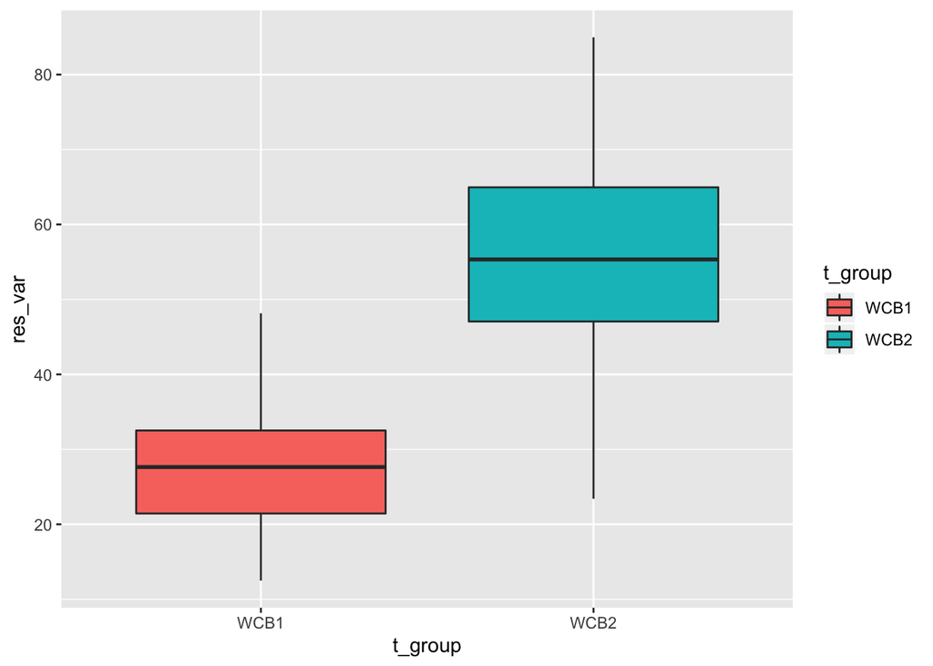

```r
# ggplot for ANOVA data ---------------------------------------------------
library(ggplot2)


ano_plot <- ggplot(data=ano_data,
                   aes(x=t_group, # aes=specify asthetics
                       y=res_var,
                       fill=t_group)) +# fill to specify a grouping variable
                      geom_boxplot()
print(ano_plot)
```

# My observations about from rerunning the code:

The first time that I ran the code I got a significant P value, but the next 2 times the P value was not significant.

#### Change the parameters around: Made sample size to 10 compared to 15.

Sample size is important to see a difference, because when I had parameters of the same SD, sample size of 30 (increased from 15), and means of 25 and 30. I got a significant difference. Change the sample sizes down to 10, and the P value is now 0.1466.

#### Ran this code with my real data for sd, mean, and sample size (however they are not actually normally distributed)

I got a P value of 0.002, which makese sense that the two groups (outflows) seem to be visually different from each other.

#### Alternatively, for the effect sizes you originally hypothesized, what is the minimum sample size you would need in order to detect a statistically significant effect? Again, run the model a few times with the same parameter set to get a feeling for the effect of random variation in the data.

Even for a sample size of 6, I still got a significant P-val